[Back: Text Mining - Day 1](http://htmlpreview.github.io/?https://github.com/bea-alex/text-mining-course/blob/master/text-mining-day1.html)

# Text Mining Lesson - Day 2

In this part of the course, you will learn how to do the following:

1. Visualising lexical dispersion
2. Plotting frequency over time
3. Extracting colocations from text
4. Part-of-speech tagging text
5. Tagging named entities in text
6. Visualising a network of entities

## Setup

Before we start this part of the lesson, please check that you have installed all the necessary software listed in the [Prerequisites](https://github.com/bea-alex/text-mining-course/blob/master/prerequisites.md).

To start this lesson, you need to re-start `jupyter notebook` in your terminal, create a new jupyter notebook in the browser that opens up and import all the packages below as you did at the start of day 1 of this lesson.

```python
import nltk
import numpy
import string
import matplotlib.pyplot as plt
```

## 1. Lexical Dispersion Plot

We can plot lexical dispersion of particular tokens. Lexical dispersion is a measure of how frequently a word appears across the parts of a corpus. This plot notes the occurrences of a word and how many words from the beginning of the corpus it appears (word offsets). This is particularly useful for a corpus that covers a longer time period and for which you want to analyse how specific terms were used more or less frequently over time.

To create a lexical disperson plot, you will first load and import a different corpus, the inaugural corpus which are all US Presidential Inaugural Addresses and which are provided with NLTK.

```python
nltk.download('inaugural')
from nltk.corpus import inaugural
from nltk.text import Text
inaugural_tokens=inaugural.words()
inaugural_texts = Text(inaugural_tokens)
```

To create the lexical dispersion plot for this corpus you also need to load `dispersion_plot` from the `nltk.draw.dispersion` package. You can then call the `dispersion_plot` method given a set of parameters, including the target words you want to plot across the corpus, whether this should be done case-sensitively, and specifying the title of the plot.

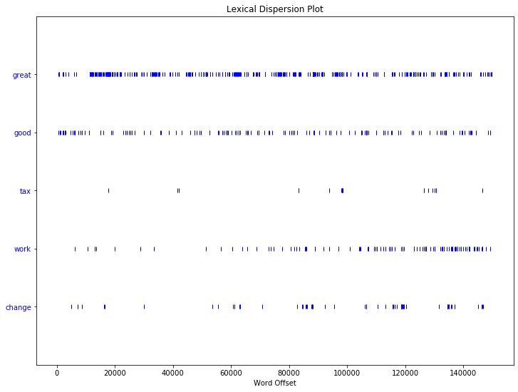

```python
from nltk.draw.dispersion import dispersion_plot

# the following command can be used to increase the size of the plot using width and hight specifications
plt.figure(figsize=(12, 9))
targets=['great','good','tax','work','change']
dispersion_plot(inaugural_texts, targets, ignore_case=True, title='Lexical Dispersion Plot')
```

## 2. Plotting frequency over time

Similarly to lexical dispersion, you can also plot frequency of terms of time. This is similarly to the [Google n-gram visualisation](https://books.google.com/ngrams) for the Google Books corpus but we will show you how to do something similar for your own corpus.

You first need to import NLTK's `ConditionalFreqDist` class from the `nltk.probability` package. To generate the graph, you have to specify the list of words to be plotted (see targets) and the x-axis labels (in this case the year the inaugural was held which appears at the start of each file: `fileid[:4]`).

The plot is created by:

- looping through each file (speech)
- then looping through each word in each speech
- then looping though the list of specified target words and
- checking if each target word matches the start of each word in the speeches (after being lower-cased).

The `ConditionalFreqDist object` (`cfd`) stores the number of times each of the target words appear in the each of the speaches and the `plot()` method is used to visualise the graph.

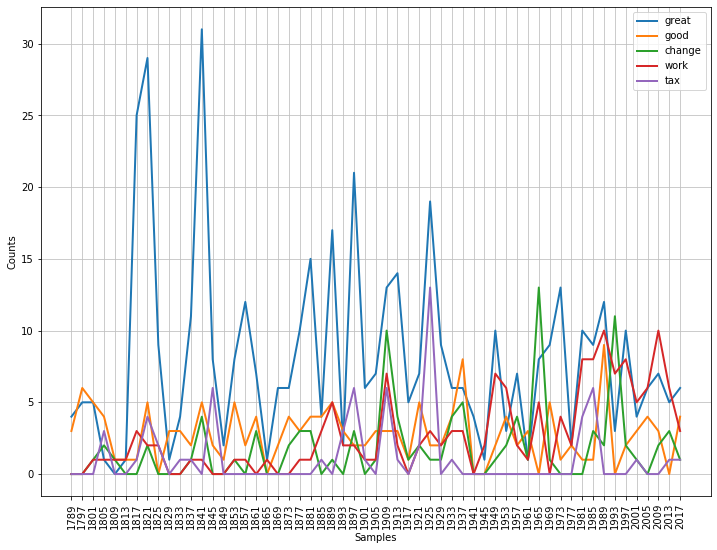

```python
from nltk.probability import ConditionalFreqDist

# type this to set the figure size
plt.rcParams["figure.figsize"] = (12, 9)

targets=['great','good','tax','work','change', 'wom[ae]n']

cfd = nltk.ConditionalFreqDist((target, fileid[:4])
    for fileid in inaugural.fileids()
    for word in inaugural.words(fileid)
    for target in targets
    if word.lower().startswith(target))
cfd.plot()
```

**Task 2.1: See how the plot changes when choosing different target words.**

**Task 2.2: Use regular expression searching to search for target words exactly instead of matching on words that start with the target words.**

## 3. Collocations

We may want to see what terms are often used together. We can do this by looking for collocations in a text, i.e. two word tokens occurring together in the text more often than would be expected by chance.

For this we need to import the `nltk.collocations` module and more specifically `BigramAssocMeasures()` and `BigramCollocationFinder`. We allow a window of 5 words between collocated words.

```python
from nltk.collocations import BigramAssocMeasures
from nltk.collocations import BigramCollocationFinder

bigram_measures = BigramAssocMeasures()
finder = BigramCollocationFinder.from_words(inaugural_tokens, 5)
```

```python
finder.apply_freq_filter(7)
```

A number of measures are available to score collocations or other associations including `bigram_measures.likelihood_ratio`. We apply this measure below and show the top ten collocated tokens (occuring in a window of 5 tokens with a frequency of 7 or more).

```python
finder.nbest(bigram_measures.likelihood_ratio, 10)
```

```
[('the', 'of'),
 ("'", 's'),
 ('.', 'The'),
 ('.', 'We'),
 ('United', 'States'),
 ('has', 'been'),
 ('.', '.'),
 ('have', 'been'),
 ('.', 'It'),
 (',', 'and')]
```

**Task 3.1: Change the code above to display collocations in the inaugural speeches after stopwords, punctuation and single digits have been removed. Refer back to Section 7 on frequency distribution for help.**

## 4. Part-of-speech tagging text

In text mining it can be useful to extract words that have a particular part of speech (POS) such as a noun or a verb. For example extracting all proper nouns can give use names and locations. This is done using a POS-tagger. The POS-tag of a word is a label of the word indicating its part of speech as well as grammatical categories such as tense, number (plural/singular) and case. POS tagging is the process of automatically determining the POS-tags of the tokens in a corpus.

In this lesson, we will use NLTK’s `averaged_perceptron_tagger` as the POS-tagger. It uses the perceptron algorithm to predict which POS-tag is most likely given the word. We need to download the tagger in order to use it.

The POS-tagger outputs tokens tagged with their POS-tag. It uses the [Penn Treebank POS tagset](https://www.ling.upenn.edu/courses/Fall_2003/ling001/penn_treebank_pos.html) which is widely used for POS-tagging text.

POS-tagging text is very useful when analysing a corpus or document and will allow us to do more indepth analysis and visualisations. In order to pos-tag using NLTK, you also have to import `pos_tag` from the `tag` package.

We are going to use the text from the US Presidential Inaugaral speeches. This is a data set that we can download from NLTK.

```python
import nltk
nltk.download('averaged_perceptron_tagger')
from nltk.tag import pos_tag
nltk.download('inaugural')
from nltk.corpus import inaugural
```

This corpus comes in raw format but also pre-tokenised. Therefore we can call the `words()` method to retrieve the tokenised text of all speeches.

```python
inaugural_tokens=inaugural.words()
print(inaugural_tokens)
```

```
['Fellow', '-', 'Citizens', 'of', 'the', 'Senate', ...]
```

```python
inaugural_tokens_trump = inaugural.words(inaugural.fileids()[0:-1])
print(inaugural_tokens_trump)
```

```
['Fellow', '-', 'Citizens', 'of', 'the', 'Senate', ...]
```

We can assign POS-tags to all speeches using NLTK's `pos_tag()` method and view the first 20:

```python
tagged_inaugural_tokens = nltk.pos_tag(inaugural_tokens)
tagged_inaugural_tokens[:20]
```

```
[('Fellow', 'NNP'),
 ('-', ':'),
 ('Citizens', 'NNS'),
 ('of', 'IN'),
 ('the', 'DT'),
 ('Senate', 'NNP'),
 ('and', 'CC'),
 ('of', 'IN'),
 ('the', 'DT'),
 ('House', 'NNP'),
 ('of', 'IN'),
 ('Representatives', 'NNPS'),
 (':', ':'),
 ('Among', 'IN'),
 ('the', 'DT'),
 ('vicissitudes', 'NNS'),
 ('incident', 'NN'),
 ('to', 'TO'),
 ('life', 'NN'),
 ('no', 'DT')]
```

We can then set up lists to hold specific parts of speech such as nouns. Firstly we set up an empty list and the we search for the nouns, NN singular and NNS plural. We can then print the first 20:

```python
nouns = []
nouns = [word for (word, pos) in tagged_inaugural_tokens if (pos == 'NN' or pos == 'NNS')]
nouns[:20]
```

```
['Citizens',
 'vicissitudes',
 'incident',
 'life',
 'event',
 'anxieties',
 'notification',
 'order',
 'day',
 'month',
 'hand',
 'Country',
 'voice',
 'veneration',
 'love',
 'retreat',
 'predilection',
 'flattering',
 'hopes',
 'decision']
```

Now that we have created this list of nouns, we can plot their counts in the corpus as we did yesterday (see lesson on frequency counts).

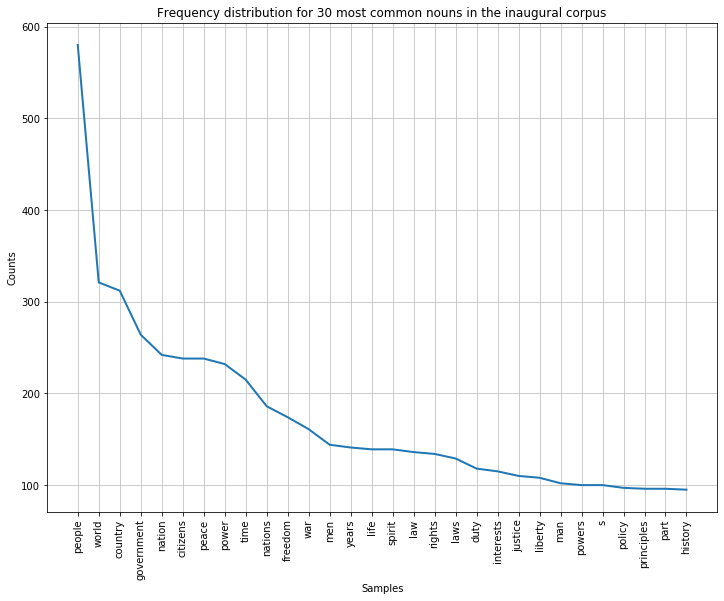

```python
from nltk.probability import FreqDist
fdist = FreqDist(nouns)
fdist.plot(30,title='Frequency distribution for 30 most common nouns in the inaugural corpus')
```

We can also plot the nouns as a word cloud like we did yesterday (see lesson on Counting tokens in text):

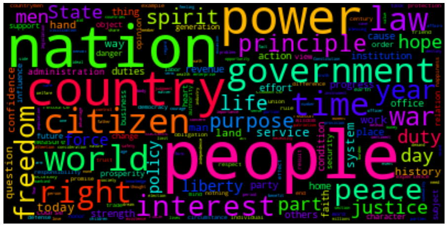

```python
from wordcloud import WordCloud
%matplotlib inline
import matplotlib.pyplot as plt
cloud = WordCloud(max_font_size=60,colormap="hsv").generate(' '.join(nouns))
plt.rcParams["figure.figsize"] = (16,12)
plt.imshow(cloud, interpolation='bilinear')
plt.axis('off')
plt.show()
```

**Task 4.1: Change the code above to create a frequency list for the most common adjectives in the inaugural corpus. The POS-tag for adjective is 'JJ'.**

**Task 4.2: Plot a word cloud of the adjectives in the inaugural corpus.**

**Task 4.3: You can do the same for another POS-tag. For the full list of Penn Treebank POS tags see [here](https://www.ling.upenn.edu/courses/Fall_2003/ling001/penn_treebank_pos.html).**

## 5. Named Entity Recognition

Named entity recognition (NER) or named entity tagging is a way of locating and classifying named entities in text (e.g. names of people, locations and organisations). NER can be used to identity networks of people mentioned in data or as the first step towards geo-parsing text, i.e. extracting and disambiguating locations mentioned in text. There are several off-the-shelf NER taggers that we can use. Here we will be using the spaCy tagger.

To use it, you need to first install it and load the model required to run it. You should have installed spacy as part of the [Prerequisites](https://github.com/bea-alex/text-mining-course/blob/master/prerequisites.md) but if not then go back to do that now before you import spacy and load the model.

```python
import spacy
nlp = spacy.load("en_core_web_sm")
```

We have already loaded the inaugural corpus from NLTK as an example. So we will use their raw text (inaugural.raw()) as input to tag it with named entities (in this case names of people, organisations and locations). To do that we just call nlp() on that list of word tokens. This can take a few seconds as it has to process all of the inaugural corpus. The results are stored in the variable doc.

```python
text=inaugural.raw()
doc = nlp(text)
```

We can then print the first 10 entities found in the text and their entity tags using a for loop:

```python
for i in range(10):
    print(doc.ents[i].text + ", " + doc.ents[i].label_)
```

```
Senate, ORG
the House of Representatives, ORG
the 14th day, DATE
the present month, DATE
every day, DATE
first, ORDINAL
the United States a Government, GPE
the United States, GPE
republican, NORP
American, NORP
```

We can save the entities separately in a list of tuples by extracting them for the output `doc` and then print the first 50 entries of that list:

```python
ents=doc.ents
named_entities = [(ent.text, ent.label_) for ent in ents]
named_entities[:50]
```

```
[('Senate', 'ORG'),
 ('the House of Representatives', 'ORG'),
 ('the 14th day', 'DATE'),
 ('the present month', 'DATE'),
 ('every day', 'DATE'),
 ('first', 'ORDINAL'),
 ('the United States a Government', 'GPE'),
 ('the United States', 'GPE'),
 ('republican', 'NORP'),
 ('American', 'NORP'),
 ('fifth', 'ORDINAL'),
 ('Constitution', 'LAW'),
 ('the House of Representatives', 'ORG'),
 ('first', 'ORDINAL'),
 ('the Human Race', 'ORG'),
 ('American', 'NORP'),
 ('America', 'GPE'),
 ('Constitution', 'LAW'),
 ('first', 'ORDINAL'),
 ('America', 'GPE'),
 ('Providence', 'GPE'),
 ('first', 'ORDINAL'),
 ('more than half', 'CARDINAL'),
 ('the Revolutionary war', 'EVENT'),
 ('Confederation', 'ORG'),
 ('Batavian', 'NORP'),
 ('Helvetic', 'PRODUCT'),
 ('a single day', 'DATE'),
 ('Congress', 'ORG'),
 ('Negligence', 'MONEY'),
 ('States', 'GPE'),
 ('States', 'GPE'),
 ('America', 'GPE'),
 ('Constitution of Government', 'LAW'),
 ('first', 'ORDINAL'),
 ('Constitution', 'LAW'),
 ('the United States', 'GPE'),
 ('Executive', 'ORG'),
 ('Senate', 'ORG'),
 ('Congress', 'ORG'),
 ('State', 'ORG'),
 ('Constitution', 'LAW'),
 ('ten years', 'DATE'),
 ('Constitution', 'LAW'),
 ('Chamber of Congress', 'ORG'),
 ('the Executive authority', 'ORG'),
 ('Legislature', 'ORG'),
 ('Government', 'ORG'),
 ('American', 'NORP'),
 ('America', 'GPE')]
```

You can do the same for specific entity types (e.g. organisation (ORG) or person (PER). At this point we will introduce the concept of function to make this easily repeatable for different types.

**Function:** A function is a block of code that can be called to complete a task. In Python a function is defined using the `def` keyword. The name of the function is specified after `def` and the parameters passed to the function are specified in round brackets after the name. The indented bit of code after the function specifies everything that the function computes. A function can return data as a result of the computation it has performed using the `return` keyword.

You have already used functions previously in this course (e.g. `print()`, `len()` etc). Now you will learn how to write a function yourself.

Below is the `get_entities_of_type()` function. It contains code that extracts named entities of a specific type from the NER-tagged output. This function takes as input the chose type (`type`), goes through each entity in teh `named_entities` list, and retains the entities if the match the type. The final list returned by the function contains only the entities of the specified type marked up in the text.

```python
def get_entities_of_type(type):
    ents = [string for (string, tag) in named_entities if (tag == type)]
    print("Number of strings tagged as " + type + " " + str(len(ents)))
    return ents
```

To run the function you need to specify the type and the output list can be stored in a new variable (people). You can then inspect the first few person entities and you will see that the tagger is not always correct (e.g. Jealous, Distinct).

```python
type="PERSON"
people = get_entities_of_type(type)
people[:10]
```

```
Number of strings tagged as PERSON 171
```

```
['Creator',
 'Jealous',
 'Distinct',
 'Roman',
 'Jefferson',
 'Madison',
 'Jefferson',
 'Caesar',
 'Roman',
 'Jefferson']
```

We can plot the entites extracted by their frequency or create word clouds for them (as we did in the previous lesson). For example, we can create a word cloud just for the person names mentioned in the corpus.

To do that we need to create a Counter dictionary containing the counts for each repetition of an entity. A Counter is a subclass of a Dictionary and elements are stored as key and their counts as values.

As you can see, spaCy recognised 109 unique person names in the inaugural speeches, some of them occurring more than others.

```python
from collections import Counter
people_dict=Counter(people)
print("Number of unique person names: " + str(len(people_dict)))
print(people_dict)
```

```
Number of unique person names: 109
Counter({'God': 19, 'Jefferson': 7, 'Chief Justice': 7, 'Bush': 6, 'Speaker': 5, 'George Washington': 4, 'Clinton': 4, 'Abraham Lincoln': 3, 'Thomas Jefferson': 3, 'Creator': 2, 'Roman': 2, 'Divine Providence': 2, 'Argonne': 2, 'Johnson': 2, 'Eisenhower': 2, "O'Neill": 2, 'Mathias': 2, 'Dole': 2, 'M…
```

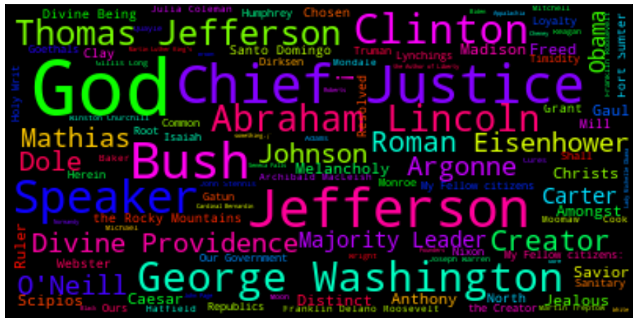

```python
cloud = WordCloud(max_font_size=50,colormap="hsv").generate_from_frequencies(people_dict)
plt.figure(figsize=(16,12))
plt.imshow(cloud, interpolation='bilinear')
plt.axis('off')
plt.show()
```

**Task 5.1: Create a similar word cloud but for the location names in the corpus.**

## 6. Visualising a network of entities

You can use network visualisations to show how things are connected in data. Networks are often used for showing networks of people in social media. Today we'll use a network visualisation to display how all US presidents are connected in terms of the people they mention in their speeches.

To do that you'll first learn how to save data to a file. The content of file serves as the input to the network. Let's first create the content (`file_content`) which we will write to a file. We'll be creating a tsv (tab-separated file), meaning that each line contains different fields separated by a tab. The first line is the header which lists the names for each column. The first column are the names of presidents and the second column the people mentioned in their speeches.

The following code was adapted from Jonathan Soma's tutorial on [NetworkX Graphs](http://jonathansoma.com/lede/algorithms-2017/classes/networks/networkx-graphs-from-source-target-dataframe/). **Note: this first bit of code takes some time to run because each speech has to be tagged individually.**

```python
header="president\tperson\n"
file_content=header
for fileid in inaugural.fileids():
    president=fileid[5:-4]
    #nertagged_words = st.tag(inaugural.words(fileid))
    doc = nlp(inaugural.raw(fileid))
    named_entities = [(ent.text, ent.label_) for ent in doc.ents]
    #named_entities=get_entities(nertagged_words)
    people = [string for (string, tag) in named_entities if (tag == 'PERSON') and (not string.startswith('\n'))]
    if len(people) > 0:
        for person in people:
            file_content=file_content + president + "\t" + person + "\n"
```

To write to a file you need to use the `open()` method and specify the file's name and mode (in this case "w" for write to file). You can then use the `write()` method and specify the content of the file in brackets. Don't forget to close the file using `close()` once you're done.

```python
f = open("presidents.tsv", "w")
f.write(file_content)
f.close()
```

You can check that file was created by looking at the Jupyter Notebook homepage in the browser. The file should now be listed in the same directory as you notebook.

We need to import two further packages to visualise a network. `pandas` is used to represent data frames. and `networkx` is needed to create a network.

```python
import pandas as pd
import networkx as nx
```

**Data frame:** A data frame is a 2-dimensional labeled data structure with columns of potentially different types.

First we create a data frame by reading in the csv file which we just created. The top of the data frame can be displayed by calling the `head()` method.

```python
df = pd.read_csv("presidents.tsv", sep='\t')
df.head()
```

|  | president | person |
| --- | --- | --- |
| 0 | Jefferson | Creator |
| 1 | Jackson | Jealous |
| 2 | VanBuren | Distinct |
| 3 | Harrison | Roman |
| 4 | Harrison | Jefferson |

The first column in the data frame will serve as the source and the second column as the target in the network. We can create a simple network specifying source and target using the headers of the columns in the data frame.

**Node:** A network node is a connection point.

**Edge:** A network edge is a connection between two nodes.

This initial network isn't very informative yet as you can't see who each node (blue circles) refers to. So next we need to make it more pretty.

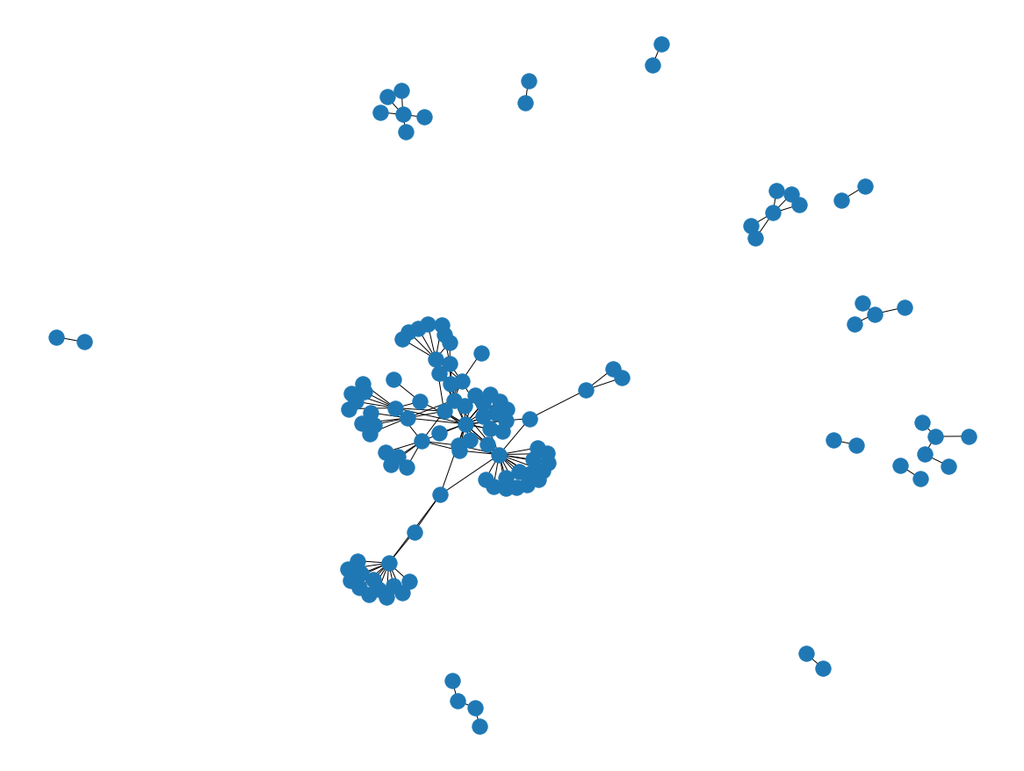

```python
g = nx.from_pandas_edgelist(df, source='president', target='person')
nx.draw(g)
```

First we need to create a list of all presidents by extracting their names from the data frame and removing repetitions. Note, these are only presidents whose speeches contain person names tagged by the NER tagger.

```python
presidents = list(df.president.unique())
presidents
```

```
['Jefferson',
 'Jackson',
 'VanBuren',
 'Harrison',
 'Polk',
 'Taylor',
 'Buchanan',
 'Grant',
 'Hayes',
 'Cleveland',
 'McKinley',
 'Roosevelt',
 'Taft',
 'Wilson',
 'Harding',
 'Coolidge',
 'Hoover',
 'Truman',
 'Eisenhower',
 'Kennedy',
 'Nixon',
 'Carter',
 'Reagan',
 'Bush',
 'Clinton',
 'Obama',
 'Trump']
```

We'll do the same for the names of people recognised in the speeches.

```python
people = list(df.person.unique())
people
```

```
['Creator',
 'Jealous',
 'Distinct',
 'Roman',
 'Jefferson',
 'Madison',
 'Caesar',
 'Amongst',
 'Christs',
 'Savior',
 'Anthony',
 'Scipios',
 'Gaul',
 'Ruler',
 'Freed',
 'Melancholy',
 'the Rocky Mountains',
 'Divine Being',
 'Chosen',
 'Divine Providence',
 'Santo Domingo',
 'Fort Sumter',
 'North',
 'Grant',
 'Mill',
 'Clay',
 'Webster',
 'Loyalty',
 'Lynchings',
 'Abraham Lincoln',
 'Monroe',
 'Our Government',
 'Root',
 'Gatun',
 'Goethals',
 'Sanitary',
 'Ours',
 'Herein',
 'Holy Writ',
 'Common',
```

[output cut: 51 more lines]

```
 'Carter',
 'Founders',
 '¡',
 'the Author of Liberty',
 'something.¡¨',
 'Normandy',
 'Biden',
 'Seneca Falls',
 'Appalachia',
 'Roberts',
 'Obama',
 'Lady Michelle Obama',
 'Black',
 'Brown',
 'White']
```

The degree of a node in a network is the number of connections it has to other nodes. For example, the degree for "Reagan" can be calculated using the `degree()` method on initial network. We will use degree as a way of varying the node size of person nodes, people with a larger degree will be displayed bigger in the network.

```python
g.degree("Reagan")
```

```
23
```

The following bit of code draws the network. The first two lines set the size of the graph and the layout of the network.

After that the different nodes are drawn using differnt parameters for node_color and node_size. Then the edges and node labels are drawn and the title of the network is specified.

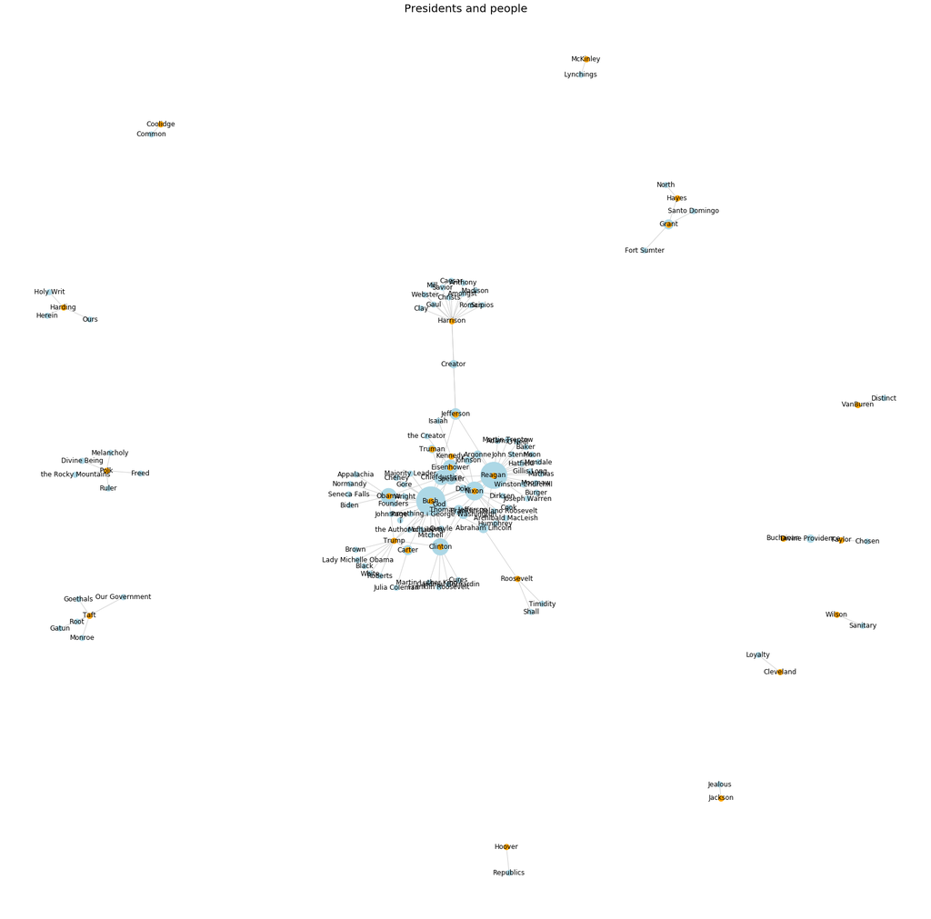

```python
# setting the size of the network
plt.figure(figsize=(30, 30))

# you can choose different ways of laying out the network
layout = nx.spring_layout(g)

# go through every person name, ask the graph how many
# connections it has. Multiply that by 100 to get the circle size
person_size = [g.degree(person) * 100 for person in people]

# draw the people nodes
nx.draw_networkx_nodes(g,
                       layout,
                       nodelist=people,
                       node_color='lightblue',
                       node_size=person_size # a list of sizes, based on g.degree
                       )

# draw president nodes
nx.draw_networkx_nodes(g, layout, nodelist=presidents, node_color='wheat', node_size=100)

# popular presidents are ones which had more than one presidency
popular_president = [president for president in presidents if g.degree(president) > 0 ]

# draw popular president nodes
nx.draw_networkx_nodes(g, layout, nodelist=popular_president, node_color='orange', node_size=100)

# draw network edges
nx.draw_networkx_edges(g, layout, width=1, edge_color="#cccccc")

# draw node labels
nx.draw_networkx_labels(g, layout, font_size=12)

plt.axis('off')
plt.title("Presidents and people", fontsize=20)
plt.show()
```

[Back: Text Mining - Day 1](http://htmlpreview.github.io/?https://github.com/bea-alex/text-mining-course/blob/master/text-mining-day1.html)